# Influence of Recent Ratings on New Ratings in Yelp Business Reviews

Lukas Nick  
21.11.2015

### Are new review ratings influenced by recent ratings?

- Social Psychology suggests that other people's opinion influence our own one (see e.g. [Aesch's conformity experiments](https://en.wikipedia.org/wiki/Asch_conformity_experiments)).
- A Yelp user, when posting a business review, can see earlier ratings: will it influence his or her rating?
- …an important question for whoever is interested in unbiased ratings!

**But:** if there is a relationship between recent ratings and a new rating, doesn't that just reflect an underlying “effect” of the business (say, the business is “good”, so the rating of most users tends to be better)?

–> such a basic business factor must be distinguished, too.

### Methods and data

- Data: Yelp Dataset, containing 1.5M reviews of 481K business by 366K users
- For each business, calculate:
  - Average of 20 most recent ratings (excluding the very latest one)
  - Average of older ratings = all ratings exluding 21 latest ratings.  
    **This “average base rating” represents the “basic business factor”.**
- This implies filtering out all businesses with viewer than 41 reviews; resulting in **8086 businesses**.
- Star ratings vs base average rating (left) and recent average rating (right):

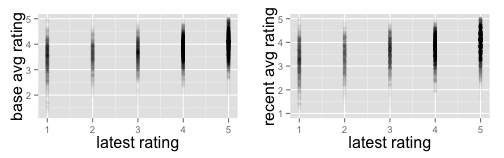

- Fit an [Ordered Logistic Regression model](http://www.ats.ucla.edu/stat/r/dae/ologit.htm) with the latest rating as dependent variable and the recent average rating as independent variable, controlling for base average rating:

```r
m <- polr(stars ~ base.avg.rating + recent.avg.rating + num.reviews, data = agg.ratings, Hess=TRUE)
```

### Results

- The coefficients of both the base average rating and recent average rating were highly significant.

```
                      Value Std. Error  t value      p value
base.avg.rating   0.5991983 0.05858597 10.22767 1.490557e-24
recent.avg.rating 0.7612637 0.05013219 15.18513 4.436986e-52
```

- The confidence intervals of their odds ratios:

```
                  OddsRatios     2.5 %   97.5 %
base.avg.rating     1.820659 1.6233182 2.042434
recent.avg.rating   2.140980 1.9408026 2.362286
num.reviews         1.000143 0.9999341 1.000356
```

- -> An increase in the base average rating by 1 star increases the *odds* for latest rating to get a higher star-rating to rise by 82%
- -> An increase in the recent average rating of 1 star raises the odds for the latest rating to get a (any) higher rating more than twice
- both confidence intervals high above 1.

### Discussion

- The recent average rating has a highly significant influence on a new rating, even when controlling for the base average rating which represents a basic business factor.
- So: the answer to the initial question is: **Yes, recent ratings do seem to influence new ratings.**

A couple of problems with the analysis:

- The “proportional odds assumption” of ordered logit models was not tested here.
- No model diagnostics available: how good is its fit?

Finally, keep in mind that this analysis only demonstrates a relationship, no causation.